# Pillow

## Installation

```
$pip install Pillow
```

## Reading an image

```python
from PIL import Image
img = Image.open("image.png")
img.show()
```

```python
img.save("temp.png")
```

## Cropping an image

```python
dim = (0,0,200,300) #Dimensions of the Reigion of Interest
crop_img = img.crop(dim)
crop_img.show()
```

get pixel values & print a grayscale image

```python
img.getpixel((100,100))
```

```
(91, 42, 35)
```

```python
img.convert('L').getpixel((100,100))
```

```
55
```

```python
grayscale = img.convert("L")
grayscale.show()
```

## Geometrical transformation

- **Resize**:

```python
resize_img = img.resize((200,200))
resize_img.show()
```

- **Rotate**:

```python
rotate_img = img.rotate(90)
rotate_img.show()
```

## Image enhancement

```python
from PIL import ImageEnhance
```

- **Change brightness**

```python
enhancer = ImageEnhance.Brightness(img)
enhancer.enhance(2).show()
```

- **Change the contrast**

```python
enhancer = ImageEnhance.Contrast(img)
enhancer.enhance(2).show()
```

# Skimage

## Installation

```
pip install skimage
```

## Start

[figure not shown]

```python
from skimage import io
img = io.imread("image.png")
io.imshow("image.png")
io.show()
```

```python
io.imsave("new_image.png",img)
```

- **Data module**:

  ```
    some standard test images
  ```

  eg:

[figure not shown]

```python
from skimage import data
io.imshow(data.camera())
io.show()
```

- **Color module**:
  - RGB to gray
  - RGB to HSV

[figure not shown]

```python
from skimage import io, color
img = io.imread("image.png")
gray = color.rgb2gray(img)
io.imshow(gray)
io.show()
```

[figure not shown]

```python
from skimage import data
img = data.astronaut()
img_hsv = color.rgb2hsv(img)
io.imshow(img_hsv)
io.show()
```

- **Draw module**:
  - Circles:

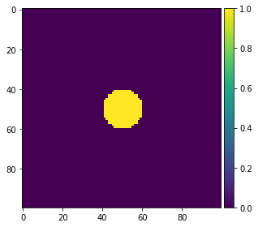

```python
import numpy as np
from skimage import io,draw
img = np.zeros((100,100),dtype=np.uint8)
x , y = draw.circle(50,50,10)
img[x,y] = 1
io.imshow(img)
io.show()
```

- Polygons:

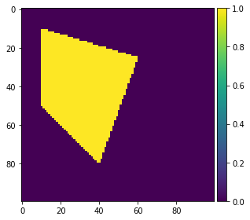

```python
import numpy as np
from skimage import io,draw
img = np.zeros((100,100),dtype=np.uint8)
r = np.array([10,25,80,50])
c = np.array([10,60,40,10])
x, y = draw.polygon(r,c)
img[x,y] = 1
io.imshow(img)
io.show()
```

# Image filters

## Gaussian blur

```python
# pillow
from PIL import Image
from PIL import ImageFilter
img = Image.open("image.png")
blur_img = img.filter(ImageFilter.GaussianBlur(5))
blur_img.show()
```

[figure not shown]

```python
# skimage
from skimage import io
from skimage import filters
img = io.imread("image.png")
out = filters.gaussian(img, sigma=5)
io.imshow(out)
io.show()
```

## Median filter

```python
# pillow
from PIL import Image
from PIL import ImageFilter
img = Image.open("image.png")
blur_img = img.filter(ImageFilter.MedianFilter(7))
blur_img.show()
```

[figure not shown]

```python
# skimage
from skimage import io
from skimage import filters
from skimage.morphology import disk
#需要用skimage.morphology模块来设置滤波器的形状。
img = data.camera()
out = filters.median(img,disk(7))
io.imshow(out)
io.show()
```

## Erosion

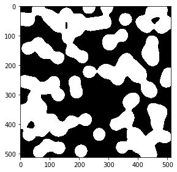

```python
from skimage import morphology
from skimage import io,data
img = data.binary_blobs()
eroded_img = morphology.binary_erosion(img)
io.imshow(eroded_img)
io.show()
```

## Dilation

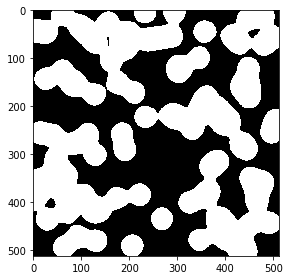

```python
dilated_img = morphology.binary_dilation(img)

io.imshow(dilated_img)
io.show()
```

## Custom filters

```python
from PIL import Image
from PIL import ImageFilter
img = Image.open("image.png")
img = img.convert("L")
new_img = img.filter(ImageFilter.Kernel((3,3), [1,0,-1,5,0,-5,1,0,1]))
new_img.show()
```

# Image thresholding

[figure not shown]

```python
from skimage.filters import threshold_otsu,threshold_adaptive
from skimage.io import imread, imsave
from skimage.color import rgb2gray

img = imread('image.png')
img = rgb2gray(img)

thresh_value = threshold_otsu(img)
thresh_img = img > thresh_value

io.imshow(thresh_img)
io.show()
```

# Edge detection

## Sobel edge detector

**sobel** function takes a 2D array as input;therefore,you will have to convert the image into a grayscale image first.

[figure not shown]

```python
from skimage import io
from skimage import filters
from skimage import color
img = io.imread("image.png")
img = color.rgb2gray(img)
edge = filters.sobel(img)
io.imshow(edge)
io.show()
```

## Canny edge detector

Four major steps:

1. Smoothing
2. Finding the gradient
3. Nonmaximal suppression
4. Thresholding

[figure not shown]

```python
from skimage import io
from skimage import feature
from skimage import color
img = io.imread("image.png")
img = color.rgb2gray(img)
edge = feature.canny(img,1)
io.imshow(edge)
io.show()
```

## Hough line

> [参考python数字图像处理](https://link.jianshu.com/?t=http%3A%2F%2Fwww.cnblogs.com%2Fdenny402%2Fp%2F5121501.html)

在图片处理中，霍夫变换主要是用来检测图片中的几何形状，包括直线、圆、椭圆等。对于平面中的一条直线，在笛卡尔坐标系中，可用 $y=mx+b$ 来表示，通常我们在极坐标中表示直线，即 $r=xcos(\theta)+ysin(\theta)$。即可用 $（r,\theta）$ 来表示一条直线。其中r为该直线到原点的距离，$\theta$ 为该直线的垂线与x轴的夹角。

[figure not shown]

上图所示，三个点(对应图中的三条正弦曲线）在一条直线上，因为这三个曲线交于一点，具有相同的 $（r, \theta)$ 。霍夫线变换就是利用这种方法来寻找图中的直线。 函数：

```
skimage.transform.hough_line(img)
```

返回三个值：

h: 霍夫变换累积器

$\theta$ : 点与x轴的夹角集合，一般为0-179度

distance: 点到原点的距离，即上面的所说的r.

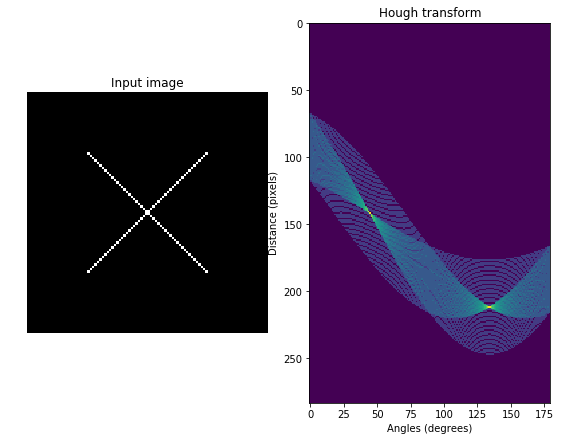

```python
import skimage.transform as st
import numpy as np
import matplotlib.pyplot as plt
#matplotlib inline

# 构建测试图片
image = np.zeros((100, 100))  #背景图
idx = np.arange(25, 75)    #25-74序列
image[idx[::-1], idx] = 255  # 线条\
image[idx, idx] = 255        # 线条/

# hough线变换
h, theta, d = st.hough_line(image)

#生成一个一行两列的窗口（可显示两张图片）.
fig, (ax0, ax1) = plt.subplots(1, 2, figsize=(8, 6))
plt.tight_layout()

#显示原始图片
ax0.imshow(image, plt.cm.gray)
ax0.set_title('Input image')
ax0.set_axis_off()

#显示hough变换所得数据
ax1.imshow(np.log(1 + h))
ax1.set_title('Hough transform')
ax1.set_xlabel('Angles (degrees)')
ax1.set_ylabel('Distance (pixels)')
ax1.axis('image')
plt.show()
```

从右边那张图可以看出，有两个交点，说明原图像中有两条直线。 如果我们要把图中的两条直线绘制出来，则需要用到另外一个函数：

```
skimage.transform.hough_line_peaks(hspace, angles, dists）
```

用这个函数可以取出峰值点，即交点，也即原图中的直线。 返回的参数与输入的参数一样。我们修改一下上边的程序，在原图中将两直线绘制出来。

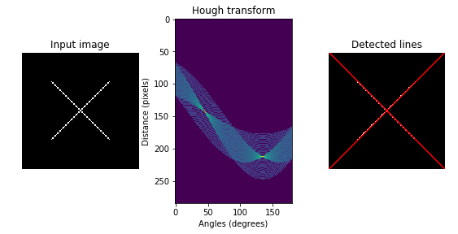

```python
import skimage.transform as st
import numpy as np
import matplotlib.pyplot as plt

# 构建测试图片
image = np.zeros((100, 100))  #背景图
idx = np.arange(25, 75)    #25-74序列
image[idx[::-1], idx] = 255  # 线条\
image[idx, idx] = 255        # 线条/

# hough线变换
h, theta, d = st.hough_line(image)

#生成一个一行三列的窗口（可显示三张图片）.
fig, (ax0, ax1,ax2) = plt.subplots(1, 3, figsize=(8, 6))
plt.tight_layout()

#显示原始图片
ax0.imshow(image, plt.cm.gray)
ax0.set_title('Input image')
ax0.set_axis_off()

#显示hough变换所得数据
ax1.imshow(np.log(1 + h))
ax1.set_title('Hough transform')
ax1.set_xlabel('Angles (degrees)')
ax1.set_ylabel('Distance (pixels)')
ax1.axis('image')

#显示检测出的线条
ax2.imshow(image, plt.cm.gray)
row1, col1 = image.shape
for _, angle, dist in zip(*st.hough_line_peaks(h, theta, d)):
    y0 = (dist - 0 * np.cos(angle)) / np.sin(angle)
    y1 = (dist - col1 * np.cos(angle)) / np.sin(angle)
    ax2.plot((0, col1), (y0, y1), '-r')
ax2.axis((0, col1, row1, 0))
ax2.set_title('Detected lines')
ax2.set_axis_off()
plt.show()
```

注意，绘制线条的时候，要从极坐标转换为笛卡尔坐标，公式为： $$y = - {cos(\theta) \over sin(\theta)}x + {r \over sin(\theta)}$$

skimage还提供了另外一个检测直线的霍夫变换函数， **概率霍夫线变换**：

[output not shown]

参数：

```
img: 待检测的图像。
threshold： 阈值，可先项，默认为10
line_length: 检测的最短线条长度，默认为50
line_gap: 线条间的最大间隙。增大这个值可以合并破碎的线条。默认为10
```

返回：

```
lines: 线条列表, 格式如((x0, y0), (x1, y0))，标明开始点和结束点。
```

下面，我们用canny算子提取边缘，然后检测哪些边缘是直线？

```
1361
```

[figure not shown]

```python
import skimage.transform as st
import matplotlib.pyplot as plt
from skimage import data,feature

#使用Probabilistic Hough Transform.
image = data.camera()
edges = feature.canny(image, sigma=2, low_threshold=1, high_threshold=25)
lines = st.probabilistic_hough_line(edges, threshold=10, line_length=5,line_gap=3)
print(len(lines))
# 创建显示窗口.
fig, (ax0, ax1, ax2) = plt.subplots(1, 3, figsize=(16, 6))
plt.tight_layout()

#显示原图像
ax0.imshow(image, plt.cm.gray)
ax0.set_title('Input image')
ax0.set_axis_off()

#显示canny边缘
ax1.imshow(edges, plt.cm.gray)
ax1.set_title('Canny edges')
ax1.set_axis_off()

#用plot绘制出所有的直线
ax2.imshow(edges * 0)
for line in lines:
    p0, p1 = line
    ax2.plot((p0[0], p1[0]), (p0[1], p1[1]))
row2, col2 = image.shape
ax2.axis((0, col2, row2, 0))
ax2.set_title('Probabilistic Hough')
ax2.set_axis_off()
plt.show()
```

在极坐标中，圆的表示方式为：

```
x=x0+rcosθ
y=y0+rsinθ
```

圆心为(x0,y0),r为半径，θ为旋转度数，值范围为0-359 如果给定圆心点和半径，则其它点是否在圆上，我们就能检测出来了。在图像中，我们将每个非0像素点作为圆心点，以一定的半径进行检测，如果有一个点在圆上，我们就对这个圆心累加一次。如果检测到一个圆，那么这个圆心点就累加到最大，成为峰值。因此，在检测结果中，一个峰值点，就对应一个圆心点。

**霍夫圆检测的函数**：

```
skimage.transform.hough_circle(image, radius)
```

radius是一个数组，表示半径的集合，如[3，4，5，6] 返回一个3维的数组（radius index, M, N), 第一维表示半径的索引，后面两维表示图像的尺寸。

椭圆变换是类似的，使用函数为：

```
skimage.transform.hough_ellipse(img,accuracy, threshold, min_size, max_size)
```